# Homework Assignment 1

Nicole Veit,Konstantinos Chiotinis

Due EoD Sun Oct 31, 2021

## HW-1 Instructions

> Our class emphasizes clear communication of data analysis results to non-technical audiences. I expect your HTML output documents to be readable and well formatted. I expect you to put ample comments in your R code to make the code understandable. Along with accuracy of results, I am looking for quality of presentation as well. To complete this assignment, follow these steps:
1. Download the `HW1.Rmd` file from Canvas.
2. Open `HW1.Rmd` in RStudio. Replace the “Your Name Here” text in the `author:` field with your name.
3. Supply your solutions to the homework by editing `HW1.Rmd`.
4. Run your code in the Console and Knit HTML frequently to check for errors.
5. You may find it easier to solve a problem by interacting only with the Console at first.
6. When you have completed the homework please check that your knits correctly when you click `Knit HTML`.
7. Submit your RMD file and the HTML output.

## Data frame basics

We will work with the nycflights dataset. **Please be sure to keep the data file in the same directory as the RMD file - your project directory.** and make that directory the working directory.

First - make sure that you are reading the data correctly and doing all the data cleaning steps that we did in class. Feel free to go beyond our class work in cleaning the data if you feel the need.

```r
#Reading and exploring data
nyc <- read.csv("nycflights.csv")
head(nyc, n = 10)
```

```
##     X year month day dep_time sched_dep_time dep_delay arr_time sched_arr_time
## 1   1 2013     1   1      517            515         2      830            819
## 2   2 2013     1   1      533            529         4      850            830
## 3   3 2013     1   1      542            540         2      923            850
## 4   4 2013     1   1      544            545        -1     1004           1022
## 5   5 2013     1   1      554            600        -6      812            837
## 6   6 2013     1   1      554            558        -4      740            728
## 7   7 2013     1   1      555            600        -5      913            854
## 8   8 2013     1   1      557            600        -3      709            723
## 9   9 2013     1   1      557            600        -3      838            846
## 10 10 2013     1   1      558            600        -2      753            745
##    arr_delay carrier flight tailnum origin dest air_time distance hour minute
## 1         11      UA   1545  N14228    EWR  IAH      227     1400    5     15
## 2         20      UA   1714  N24211    LGA  IAH      227     1416    5     29
## 3         33      AA   1141  N619AA    JFK  MIA      160     1089    5     40
```

[output cut: 18 more lines]

```r
str(nyc)
```

```
## 'data.frame':    336776 obs. of  20 variables:
##  $ X             : int  1 2 3 4 5 6 7 8 9 10 ...
##  $ year          : int  2013 2013 2013 2013 2013 2013 2013 2013 2013 2013 ...
##  $ month         : int  1 1 1 1 1 1 1 1 1 1 ...
##  $ day           : int  1 1 1 1 1 1 1 1 1 1 ...
##  $ dep_time      : int  517 533 542 544 554 554 555 557 557 558 ...
##  $ sched_dep_time: int  515 529 540 545 600 558 600 600 600 600 ...
##  $ dep_delay     : int  2 4 2 -1 -6 -4 -5 -3 -3 -2 ...
##  $ arr_time      : int  830 850 923 1004 812 740 913 709 838 753 ...
##  $ sched_arr_time: int  819 830 850 1022 837 728 854 723 846 745 ...
##  $ arr_delay     : int  11 20 33 -18 -25 12 19 -14 -8 8 ...
##  $ carrier       : chr  "UA" "UA" "AA" "B6" ...
##  $ flight        : int  1545 1714 1141 725 461 1696 507 5708 79 301 ...
##  $ tailnum       : chr  "N14228" "N24211" "N619AA" "N804JB" ...
##  $ origin        : chr  "EWR" "LGA" "JFK" "JFK" ...
##  $ dest          : chr  "IAH" "IAH" "MIA" "BQN" ...
##  $ air_time      : int  227 227 160 183 116 150 158 53 140 138 ...
##  $ distance      : int  1400 1416 1089 1576 762 719 1065 229 944 733 ...
##  $ hour          : int  5 5 5 5 6 5 6 6 6 6 ...
##  $ minute        : int  15 29 40 45 0 58 0 0 0 0 ...
##  $ time_hour     : chr  "1/1/2013 5:00" "1/1/2013 5:00" "1/1/2013 5:00" "1/1/2013 5:00" ...
```

```r
summary(nyc)
```

```
##        X               year          month             day
##  Min.   :     1   Min.   :2013   Min.   : 1.000   Min.   : 1.00
##  1st Qu.: 84195   1st Qu.:2013   1st Qu.: 4.000   1st Qu.: 8.00
##  Median :168389   Median :2013   Median : 7.000   Median :16.00
##  Mean   :168389   Mean   :2013   Mean   : 6.549   Mean   :15.71
##  3rd Qu.:252582   3rd Qu.:2013   3rd Qu.:10.000   3rd Qu.:23.00
##  Max.   :336776   Max.   :2013   Max.   :12.000   Max.   :31.00
##
##     dep_time    sched_dep_time   dep_delay          arr_time    sched_arr_time
##  Min.   :   1   Min.   : 106   Min.   : -43.00   Min.   :   1   Min.   :   1
##  1st Qu.: 907   1st Qu.: 906   1st Qu.:  -5.00   1st Qu.:1104   1st Qu.:1124
##  Median :1401   Median :1359   Median :  -2.00   Median :1535   Median :1556
##  Mean   :1349   Mean   :1344   Mean   :  12.64   Mean   :1502   Mean   :1536
##  3rd Qu.:1744   3rd Qu.:1729   3rd Qu.:  11.00   3rd Qu.:1940   3rd Qu.:1945
##  Max.   :2400   Max.   :2359   Max.   :1301.00   Max.   :2400   Max.   :2359
##  NA's   :8255                  NA's   :8255      NA's   :8713
##    arr_delay          carrier              flight       tailnum
##  Min.   : -86.000   Length:336776      Min.   :   1   Length:336776
##  1st Qu.: -17.000   Class :character   1st Qu.: 553   Class :character
##  Median :  -5.000   Mode  :character   Median :1496   Mode  :character
##  Mean   :   6.895                      Mean   :1972
##  3rd Qu.:  14.000                      3rd Qu.:3465
##  Max.   :1272.000                      Max.   :8500
##  NA's   :9430
##     origin              dest              air_time        distance
##  Length:336776      Length:336776      Min.   : 20.0   Min.   :  17
##  Class :character   Class :character   1st Qu.: 82.0   1st Qu.: 502
##  Mode  :character   Mode  :character   Median :129.0   Median : 872
##                                        Mean   :150.7   Mean   :1040
##                                        3rd Qu.:192.0   3rd Qu.:1389
##                                        Max.   :695.0   Max.   :4983
##                                        NA's   :9430
##       hour           minute       time_hour
##  Min.   : 1.00   Min.   : 0.00   Length:336776
##  1st Qu.: 9.00   1st Qu.: 8.00   Class :character
##  Median :13.00   Median :29.00   Mode  :character
##  Mean   :13.18   Mean   :26.23
##  3rd Qu.:17.00   3rd Qu.:44.00
##  Max.   :23.00   Max.   :59.00
##
```

### Cleaning data

```r
#Delete unnecessary columns
nyc$X <- NULL
nyc$year <- NULL
```

```r
#Factorize columns
#Flight, carrier, origin, dest, tailnum, month

nyc$flight <- as.factor(nyc$flight)
nyc$carrier <- as.factor(nyc$carrier)
nyc$origin <- as.factor(nyc$origin)
nyc$dest <- as.factor(nyc$dest)
nyc$tailnum <- as.factor(nyc$tailnum)
nyc$month <- as.factor(nyc$month)

nyc$flightdate <- as.Date(nyc$time_hour, format = "%Y-%m-%d %H:%M:%S")

str(nyc)
```

```
## 'data.frame':    336776 obs. of  19 variables:
##  $ month         : Factor w/ 12 levels "1","2","3","4",..: 1 1 1 1 1 1 1 1 1 1 ...
##  $ day           : int  1 1 1 1 1 1 1 1 1 1 ...
##  $ dep_time      : int  517 533 542 544 554 554 555 557 557 558 ...
##  $ sched_dep_time: int  515 529 540 545 600 558 600 600 600 600 ...
##  $ dep_delay     : int  2 4 2 -1 -6 -4 -5 -3 -3 -2 ...
##  $ arr_time      : int  830 850 923 1004 812 740 913 709 838 753 ...
##  $ sched_arr_time: int  819 830 850 1022 837 728 854 723 846 745 ...
##  $ arr_delay     : int  11 20 33 -18 -25 12 19 -14 -8 8 ...
##  $ carrier       : Factor w/ 16 levels "9E","AA","AS",..: 12 12 2 4 5 12 4 6 4 2 ...
##  $ flight        : Factor w/ 3844 levels "1","2","3","4",..: 1382 1545 1042 677 425 1527 469 3700 69 266 ...
##  $ tailnum       : Factor w/ 4043 levels "D942DN","N0EGMQ",..: 180 524 2401 3204 2661 1142 1829 3300 2207 1178 ...
##  $ origin        : Factor w/ 3 levels "EWR","JFK","LGA": 1 3 2 2 3 1 1 3 2 3 ...
##  $ dest          : Factor w/ 105 levels "ABQ","ACK","ALB",..: 44 44 59 13 5 70 36 43 55 70 ...
##  $ air_time      : int  227 227 160 183 116 150 158 53 140 138 ...
##  $ distance      : int  1400 1416 1089 1576 762 719 1065 229 944 733 ...
##  $ hour          : int  5 5 5 5 6 5 6 6 6 6 ...
##  $ minute        : int  15 29 40 45 0 58 0 0 0 0 ...
##  $ time_hour     : chr  "1/1/2013 5:00" "1/1/2013 5:00" "1/1/2013 5:00" "1/1/2013 5:00" ...
##  $ flightdate    : Date, format: NA NA ...
```

I now would like you to answer the following - all in their own separate R code blocks.

### Data Exploration

Let’s first do some simple exploration of this data.

- How many airlines are there? (Hint: `nlevels` or ‘levels’ and `length` can be useful here)

```r
nlevels(nyc$carrier)
```

```
## [1] 16
```

```r
length(levels(nyc$carrier))
```

```
## [1] 16
```

- How many flights there were by the airline with code `OO`? (Hint: `nrow` can be useful here along with logical indexing)

```r
nycOO <- nyc[ nyc$carrier == "OO",]
nrow(nycOO)
```

```
## [1] 32
```

- How long is the shortest flight out of any NYC airport? (Hint: `min` can be useful, remember to handle `NA` values)

```r
min(nyc$air_time,na.rm = TRUE)
```

```
## [1] 20
```

- How many flights where there by United Airlines (code: UA) on Jan 12th 2013?

```r
nycUA <- nyc[ nyc$carrier == "UA" & nyc$month == 1 & nyc$day == 12,]
nrow(nycUA)
```

```
## [1] 112
```

### Arrival Delay

Lets focus on Arrival Delay.

- What was the average arrival delay for all airports and all airlines combined in 2013?

```r
mean(nyc$arr_delay, na.rm = TRUE)
```

```
## [1] 6.895377
```

- Whats was the median arrival delay for all airports and all airlines combined in 2013?

```r
median(nyc$arr_delay, na.rm = TRUE)
```

```
## [1] -5
```

Based on your answers to the two questions above, what can you say about the distribution of arrival delays? Provide your answer in a text paragraph form.

Most flights arrive early. The distribution is positively skewed.

### Airline Performance

Lets see if all airlines are equally terrible as far as flight arrival delays are concerned. For this question you will have to make sure that airline column is coded as a factor.

- Calculate average arrival delays by airline (Hint: look up the command `tapply`)

```r
arr_delay_by_airline <- tapply(nyc$arr_delay, nyc$carrier, mean, na.rm = TRUE)

round(arr_delay_by_airline, 2)
```

```
##    9E    AA    AS    B6    DL    EV    F9    FL    HA    MQ    OO    UA    US
##  7.38  0.36 -9.93  9.46  1.64 15.80 21.92 20.12 -6.92 10.77 11.93  3.56  2.13
##    VX    WN    YV
##  1.76  9.65 15.56
```

- Draw a Bar Plot of Average Arrival Delays for all the Airlines (Hint: command for making a Bar Plot is simply `barplot`)

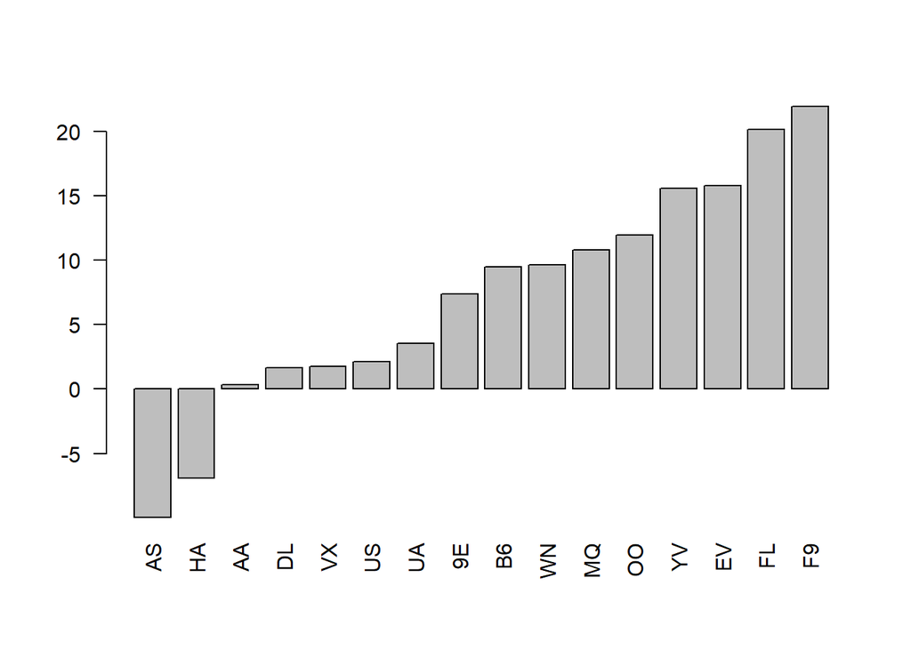

```r
barplot(sort(arr_delay_by_airline), las = 2)
```

- Which airline has the highest average arrival delay? Which airline has the smallest average arrival delay? Are there airlines that actually have negative average delay? Provide answer to this question in a text paragraph form using **inline R code**.

```r
names(arr_delay_by_airline[arr_delay_by_airline == max(arr_delay_by_airline)])
```

```
## [1] "F9"
```

```r
names(arr_delay_by_airline[arr_delay_by_airline==min(arr_delay_by_airline)])
```

```
## [1] "AS"
```

The airline with the highest average arrival delay is: F9

The airline with the lowest average arrival delay is: AS

### Air Gain

Create a new column named airgain such that airgain = (departure delay - arrival delay) : this is the amount of delay a flight made up while in air.

```r
nyc$airgain<- (nyc$dep_delay-nyc$arr_delay)
str(nyc)
```

```
## 'data.frame':    336776 obs. of  20 variables:
##  $ month         : Factor w/ 12 levels "1","2","3","4",..: 1 1 1 1 1 1 1 1 1 1 ...
##  $ day           : int  1 1 1 1 1 1 1 1 1 1 ...
##  $ dep_time      : int  517 533 542 544 554 554 555 557 557 558 ...
##  $ sched_dep_time: int  515 529 540 545 600 558 600 600 600 600 ...
##  $ dep_delay     : int  2 4 2 -1 -6 -4 -5 -3 -3 -2 ...
##  $ arr_time      : int  830 850 923 1004 812 740 913 709 838 753 ...
##  $ sched_arr_time: int  819 830 850 1022 837 728 854 723 846 745 ...
##  $ arr_delay     : int  11 20 33 -18 -25 12 19 -14 -8 8 ...
##  $ carrier       : Factor w/ 16 levels "9E","AA","AS",..: 12 12 2 4 5 12 4 6 4 2 ...
##  $ flight        : Factor w/ 3844 levels "1","2","3","4",..: 1382 1545 1042 677 425 1527 469 3700 69 266 ...
##  $ tailnum       : Factor w/ 4043 levels "D942DN","N0EGMQ",..: 180 524 2401 3204 2661 1142 1829 3300 2207 1178 ...
##  $ origin        : Factor w/ 3 levels "EWR","JFK","LGA": 1 3 2 2 3 1 1 3 2 3 ...
##  $ dest          : Factor w/ 105 levels "ABQ","ACK","ALB",..: 44 44 59 13 5 70 36 43 55 70 ...
##  $ air_time      : int  227 227 160 183 116 150 158 53 140 138 ...
##  $ distance      : int  1400 1416 1089 1576 762 719 1065 229 944 733 ...
##  $ hour          : int  5 5 5 5 6 5 6 6 6 6 ...
##  $ minute        : int  15 29 40 45 0 58 0 0 0 0 ...
##  $ time_hour     : chr  "1/1/2013 5:00" "1/1/2013 5:00" "1/1/2013 5:00" "1/1/2013 5:00" ...
##  $ flightdate    : Date, format: NA NA ...
##  $ airgain       : int  -9 -16 -31 17 19 -16 -24 11 5 -10 ...
```

1. Explore airgain data - calculate suitable descriptive statistics and appropriate graphics to better understand this data. This part is open ended - you do what you feel works best for you.

```r
airgain_by_airline<-tapply(nyc$airgain, nyc$carrier, mean, na.rm=TRUE)

round(airgain_by_airline,2)
```

```
##    9E    AA    AS    B6    DL    EV    F9    FL    HA    MQ    OO    UA    US
##  9.06  8.20 15.76  3.51  7.58  4.04 -1.72 -1.51 11.82 -0.33  0.66  8.46  1.62
##    VX    WN    YV
## 10.99  8.01  3.34
```

```r
mean(airgain_by_airline)
```

```
## [1] 5.593178
```

```r
median(airgain_by_airline)
```

```
## [1] 5.811054
```

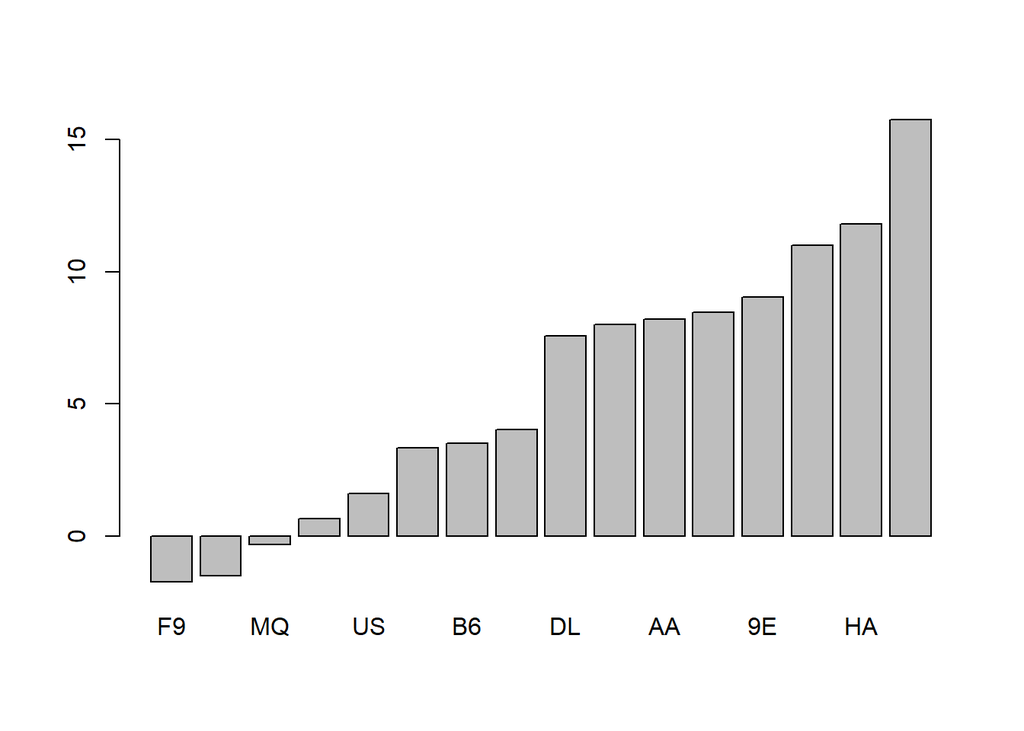

```r
barplot(sort(airgain_by_airline))
```

```r
names(airgain_by_airline[airgain_by_airline == max(airgain_by_airline)])
```

```
## [1] "AS"
```

```r
names(airgain_by_airline[airgain_by_airline==min(airgain_by_airline)])
```

```
## [1] "F9"
```

2. Answer the questions:
- do airlines actually gain any time when in air on average?
- Calculate average airgain for different airlines - which airlines do a better job, which do a worse job?

The airline with the greatest airgain is AS

The airline with the least airgain (loss) is F9

### Making Your HTML Look Nice

We want our report to be good looking, professional documents. To that end, I am asking you to do the following:

- Have a floating table of contents
- Include code folding in your output. You can find more about code folding here: https://bookdown.org/yihui/rmarkdown/html-document.html#code-folding

That’s it. Once you are done, make sure everything works and knits well and then you can push your changes to the GitHub repo and uplaod the RMD flile and the html output to Canvas.

**Have Fun!**

Sanjeev